# Practical machine learning course project

Ilya Semenov

17 June 2016

## Overview

Given the data collected from *Jawbone Up, Nike FuelBand, FitBit* devices that record personal physical activities performed by volunteers predict the manner in which they perform their exercises.

Using devices such as Jawbone Up, Nike FuelBand, and Fitbit it is now possible to collect a large amount of data about personal activity relatively inexpensively. These type of devices are part of the quantified self movement – a group of enthusiasts who take measurements about themselves regularly to improve their health, to find patterns in their behavior, or because they are tech geeks. One thing that people regularly do is quantify how much of a particular activity they do, but they rarely quantify how well they do it. In this project, your goal will be to use data from accelerometers on the belt, forearm, arm, and dumbell of 6 participants. They were asked to perform barbell lifts correctly and incorrectly in 5 different ways.

Key specific questions to answer were as follows:

- how the model were built;
- cross validation usage principles;
- what expected sample error is;
- what were the reasons for choices made;
- use final prediction model to predict 20 different test cases.

## Data sources

Data for the project were obtained as two datasets: [training](https://d396qusza40orc.cloudfront.net/predmachlearn/pml-training.csv) and [testing](https://d396qusza40orc.cloudfront.net/predmachlearn/pml-testing.csv).

## Getting and loading data

```r
suppressWarnings(suppressMessages(library(caret)))
suppressWarnings(suppressMessages(library(rpart)))
suppressWarnings(suppressMessages(library(rattle)))
suppressWarnings(suppressMessages(library(randomForest)))

url_training <- "https://d396qusza40orc.cloudfront.net/predmachlearn/pml-training.csv"
file_training <- "pml-training.csv"
if (!file.exists(file_training)) {
  download.file(url = url_training, destfile = file_training)
}

url_testing <- "https://d396qusza40orc.cloudfront.net/predmachlearn/pml-testing.csv"
file_testing <- "pml-testing.csv"
if (!file.exists(file_testing)) {
  download.file(url = url_testing, destfile = file_testing)
}

df_train <- read.csv(file_training, na.strings = c("NA", "", "<NA>"), header = TRUE)
df_test  <- read.csv(file_testing, na.strings = c("NA", "",  "<NA>"), header = TRUE)

#verify train and test datasets have similar structure
all.equal(colnames(df_train)[1:length(colnames(df_train))-1], colnames(df_test)[1:length(colnames(df_test))-1])
```

```
## [1] TRUE
```

## Training model data preparation

```r
dim(df_train)
```

```
## [1] 19622   160
```

```r
summary(df_train$classe)
```

```
##    A    B    C    D    E
## 5580 3797 3422 3216 3607
```

There are 19622 observations of 160 variables available. Prediction model bases on a *classe* variable, there are 5 different *classes* total. In order to train a model we have to split data into a training and testing datasets.

```r
set.seed(10203)
inTrain <- createDataPartition(y = df_train$classe, p = .7, list = FALSE)
training <- df_train[inTrain,]
testing <- df_train[-inTrain,]
dim(testing)
```

```
## [1] 5885  160
```

There are 159 variables available for model training (160 minus *classe*), so we need to check if reducing the number of predictors is possible. Best candidates are variables with big number of missing values.

```r
na_vars <- sapply(training, function(x) {sum(is.na(x))})
table(na_vars)
```

```
## na_vars
##     0 13468
##    60   100
```

Let remove 100 variables with almost every observation missing from training dataset.

```r
rm_cols <- names(na_vars[na_vars == 13468])
training <- training[, !names(training) %in% rm_cols]
testing <- testing[, !names(testing) %in% rm_cols] #need to remove columns in test dataset
df_test <- df_test[, !names(df_test) %in% rm_cols] #and in a control test dataset too
str(training)
```

```
## 'data.frame':    13737 obs. of  60 variables:
##  $ X                   : int  3 5 6 9 10 11 12 14 15 16 ...
##  $ user_name           : Factor w/ 6 levels "adelmo","carlitos",..: 2 2 2 2 2 2 2 2 2 2 ...
##  $ raw_timestamp_part_1: int  1323084231 1323084232 1323084232 1323084232 1323084232 1323084232 1323084232 1323084232 1323084232 1323084232 ...
##  $ raw_timestamp_part_2: int  820366 196328 304277 484323 484434 500302 528316 576390 604281 644302 ...
##  $ cvtd_timestamp      : Factor w/ 20 levels "02/12/2011 13:32",..: 9 9 9 9 9 9 9 9 9 9 ...
##  $ new_window          : Factor w/ 2 levels "no","yes": 1 1 1 1 1 1 1 1 1 1 ...
##  $ num_window          : int  11 12 12 12 12 12 12 12 12 12 ...
##  $ roll_belt           : num  1.42 1.48 1.45 1.43 1.45 1.45 1.43 1.42 1.45 1.48 ...
##  $ pitch_belt          : num  8.07 8.07 8.06 8.16 8.17 8.18 8.18 8.21 8.2 8.15 ...
##  $ yaw_belt            : num  -94.4 -94.4 -94.4 -94.4 -94.4 -94.4 -94.4 -94.4 -94.4 -94.4 ...
##  $ total_accel_belt    : int  3 3 3 3 3 3 3 3 3 3 ...
##  $ gyros_belt_x        : num  0 0.02 0.02 0.02 0.03 0.03 0.02 0.02 0 0 ...
##  $ gyros_belt_y        : num  0 0.02 0 0 0 0 0 0 0 0 ...
##  $ gyros_belt_z        : num  -0.02 -0.02 -0.02 -0.02 0 -0.02 -0.02 -0.02 0 0 ...
```

[output cut: 46 more lines]

As a final step we’ll remove an ID variable (column No 1) in *training* and *testing* datasets to avoid interference with machine learning algorithms.

```r
training <- training[c(-1)]
testing  <- testing[c(-1)]
df_test  <- df_test[c(-1)]
clean1 <- colnames(training)
clean2 <- colnames(training[, -59])
testing <- testing[clean1]
df_test <- df_test[clean2]
for (i in 1:length(df_test) ) {
     for(j in 1:length(training)) {
         if( length( grep(names(training[i]), names(df_test)[j]) ) == 1)  {
             class(df_test[j]) <- class(training[i])
         }
     }
}
df_test <- rbind(training[2, -59], df_test)
df_test <- df_test[-1,]
```

## Implementing Decision tree model

Let build a model based on a machine learning Decision tree algorithm. We’ll use ‘class’ method for all the models below since we have a classification task.

```r
modFitDT <- rpart(classe ~ ., data = training, method = "class")
```

Calculating prediction and evaluating prediction results.

```r
predictionDT <- predict(modFitDT, testing, type = "class")
cmdt <- confusionMatrix(predictionDT, testing$classe)
cmdt
```

```
## Confusion Matrix and Statistics
##
##           Reference
## Prediction    A    B    C    D    E
##          A 1620   56    6    0    0
##          B   52 1041  127   28    0
##          C    2   34  876  119   41
##          D    0    8   10  648   62
##          E    0    0    7  169  979
##
## Overall Statistics
##
##                Accuracy : 0.8775
##                  95% CI : (0.8688, 0.8858)
##     No Information Rate : 0.2845
##     P-Value [Acc > NIR] : < 2.2e-16
##
##                   Kappa : 0.8448
##  Mcnemar's Test P-Value : NA
##
## Statistics by Class:
##
##                      Class: A Class: B Class: C Class: D Class: E
## Sensitivity            0.9677   0.9140   0.8538   0.6722   0.9048
## Specificity            0.9853   0.9564   0.9597   0.9837   0.9634
## Pos Pred Value         0.9631   0.8341   0.8172   0.8901   0.8476
## Neg Pred Value         0.9872   0.9789   0.9688   0.9387   0.9782
## Prevalence             0.2845   0.1935   0.1743   0.1638   0.1839
## Detection Rate         0.2753   0.1769   0.1489   0.1101   0.1664
## Detection Prevalence   0.2858   0.2121   0.1822   0.1237   0.1963
## Balanced Accuracy      0.9765   0.9352   0.9067   0.8280   0.9341
```

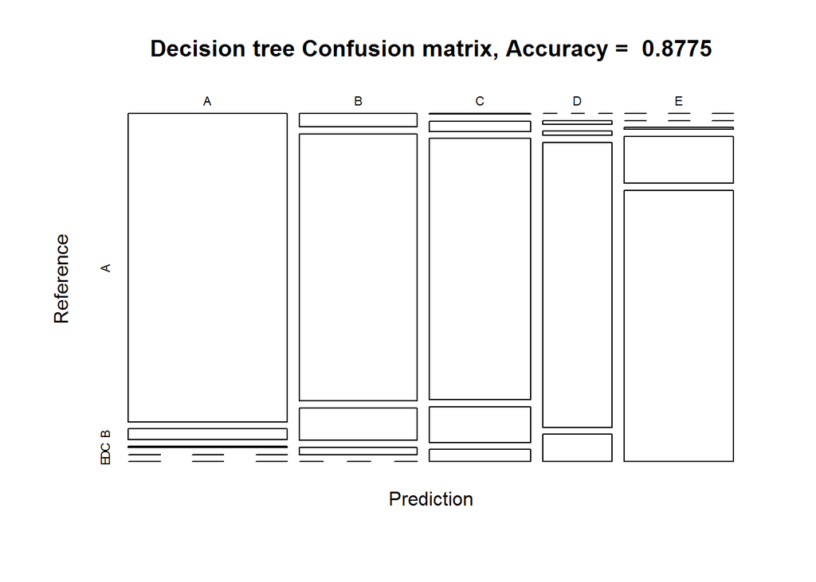

```r
plot(cmdt$table, col = cmdt$byClass, main = paste("Decision tree Confusion matrix, Accuracy = ", round(cmdt$overall['Accuracy'], 4)))
```

Prediction accuracy for Decision tree algorithm equals *0.88*.

## Implementing prediction with Random forests

Let build a model based on a Random forests prediction algorithm.

```r
set.seed(10203)
modFitRF <- randomForest(classe ~ ., data = training)
predictionRF <- predict(modFitRF, testing, type = 'class')
cmrf <- confusionMatrix(predictionRF, testing$classe)
cmrf
```

```
## Confusion Matrix and Statistics
##
##           Reference
## Prediction    A    B    C    D    E
##          A 1674    1    0    0    0
##          B    0 1138    2    0    0
##          C    0    0 1021    1    0
##          D    0    0    3  962    1
##          E    0    0    0    1 1081
##
## Overall Statistics
##
##                Accuracy : 0.9985
##                  95% CI : (0.9971, 0.9993)
##     No Information Rate : 0.2845
##     P-Value [Acc > NIR] : < 2.2e-16
##
##                   Kappa : 0.9981
##  Mcnemar's Test P-Value : NA
##
## Statistics by Class:
##
##                      Class: A Class: B Class: C Class: D Class: E
## Sensitivity            1.0000   0.9991   0.9951   0.9979   0.9991
## Specificity            0.9998   0.9996   0.9998   0.9992   0.9998
## Pos Pred Value         0.9994   0.9982   0.9990   0.9959   0.9991
## Neg Pred Value         1.0000   0.9998   0.9990   0.9996   0.9998
## Prevalence             0.2845   0.1935   0.1743   0.1638   0.1839
## Detection Rate         0.2845   0.1934   0.1735   0.1635   0.1837
## Detection Prevalence   0.2846   0.1937   0.1737   0.1641   0.1839
## Balanced Accuracy      0.9999   0.9994   0.9975   0.9986   0.9994
```

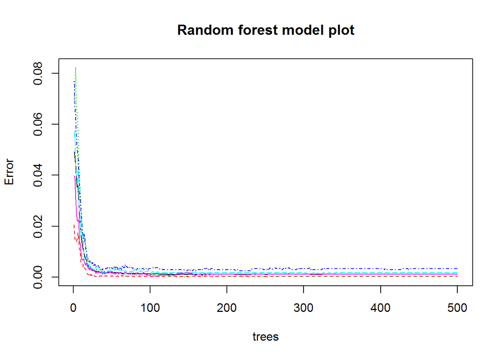

```r
plot(modFitRF, main = "Random forest model plot")
```

[figure not shown]

```r
plot(cmrf$table, col = cmrf$byClass, main = paste("Decision tree Confusion matrix, Accuracy = ", round(cmrf$overall['Accuracy'], 4)))
```

Prediction accuracy for Random forests prediction algorithm equals *0.99*.

## Implement Generalized boosted regression algorithm

Let build a model based on a Generalized boosted regression algorithm.

```r
set.seed(10203)
fitControl <- trainControl(method = 'repeatedcv', number = 5, repeats = 1)
modFitGBM <- train(classe ~ ., data = training, method = 'gbm', trControl = fitControl, verbose = FALSE)
predictionGBM <- predict(modFitGBM, newdata = testing)
cmgbm <- confusionMatrix(predictionGBM, testing$classe)
cmgbm
```

```
## Confusion Matrix and Statistics
##
##           Reference
## Prediction    A    B    C    D    E
##          A 1674    1    0    0    0
##          B    0 1136    1    0    0
##          C    0    2 1016    2    0
##          D    0    0    9  959    3
##          E    0    0    0    3 1079
##
## Overall Statistics
##
##                Accuracy : 0.9964
##                  95% CI : (0.9946, 0.9978)
##     No Information Rate : 0.2845
##     P-Value [Acc > NIR] : < 2.2e-16
##
##                   Kappa : 0.9955
##  Mcnemar's Test P-Value : NA
##
## Statistics by Class:
##
##                      Class: A Class: B Class: C Class: D Class: E
## Sensitivity            1.0000   0.9974   0.9903   0.9948   0.9972
## Specificity            0.9998   0.9998   0.9992   0.9976   0.9994
## Pos Pred Value         0.9994   0.9991   0.9961   0.9876   0.9972
## Neg Pred Value         1.0000   0.9994   0.9979   0.9990   0.9994
## Prevalence             0.2845   0.1935   0.1743   0.1638   0.1839
## Detection Rate         0.2845   0.1930   0.1726   0.1630   0.1833
## Detection Prevalence   0.2846   0.1932   0.1733   0.1650   0.1839
## Balanced Accuracy      0.9999   0.9986   0.9947   0.9962   0.9983
```

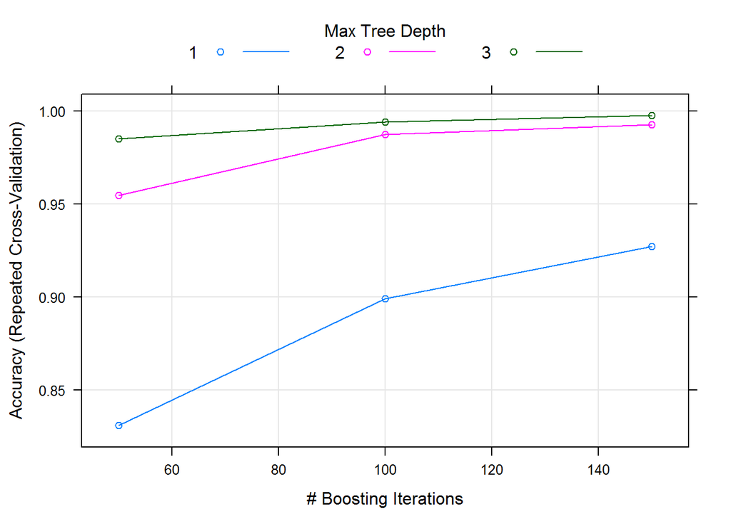

```r
plot(modFitGBM)
```

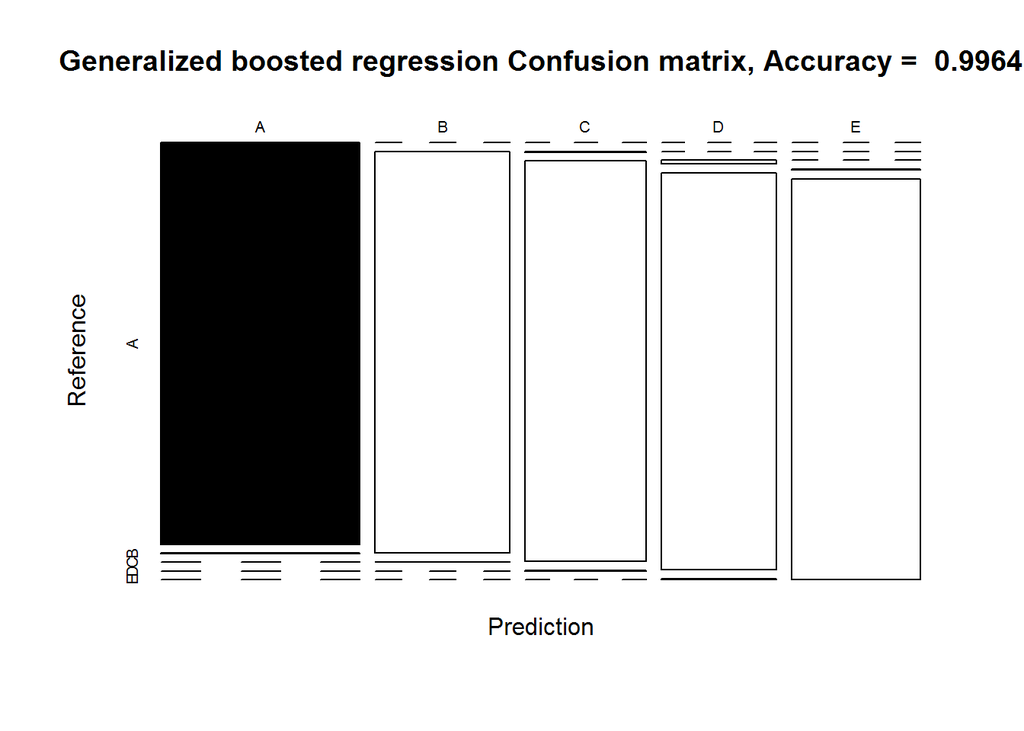

```r
plot(cmgbm$table, col = cmgbm$byClass, main = paste("Generalized boosted regression Confusion matrix, Accuracy = ", round(cmgbm$overall['Accuracy'], 4)))
```

Generalized boosted regression accuracy *0.99* appears to be only slightly worse than Random forests, but the algorithm is much more greedy for computational resources.

The best choice for a given data seems to be a Random forest algorithm since it provides highest prediction accuracy together with being fast enough.

## Prediction on a given test dataset

```r
predictionTEST <- predict(modFitRF, df_test, type = 'class')
predictionTEST
```

```
##  1  2  3  4 51  6  7  8  9 10 11 12 13 14 15 16 17 18 19 20
##  B  A  B  A  A  E  D  B  A  A  B  C  B  A  E  E  A  B  B  B
## Levels: A B C D E
```

#### Quiz answers files creation sequence

```r
write_answers = function(x) {
  n = length(x)
  for(i in 1:n)
  {
    filepath = "e:/rwd/"
    filename = paste0(filepath, "problem_id_",i,".txt")
    write.table(x[i], file = filename, quote = FALSE, row.names = FALSE,    col.names = FALSE) }
}
#write_answers(predictionTEST)
```